# Weight Lifting Exercises

*Are you doing it right?*

# Summary

The purpose of this exercise was to predict how well subjects performed weight lifting exercises. On-body sensors were used to measure several aspects of how the subjects performed the exercises. The training set contains ratings for correctly executed lifts (class A) and common mistakes (classes B-E).

A random forest model was used and proved to be very effective in predicting the classes. An out-of-sample error rate of only 0.65% was predicted by the model and confirmed by a confusion matrix created against a cross-validation set.

Further work could be done to tune the model to train more quickly (fewer trees, fewer variables).

The data set was provided by:

*Velloso, E.; Bulling, A.; Gellersen, H.; Ugulino, W.; Fuks, H. Qualitative Activity Recognition of Weight Lifting Exercises. Proceedings of 4th International Conference in Cooperation with SIGCHI (Augmented Human ’13) . Stuttgart, Germany: ACM SIGCHI, 2013.*

Read more: http://groupware.les.inf.puc-rio.br/har#ixzz3ALAfFJ9s

## Getting and Cleaning the Data

### Downloading

After reading in the data we confirm the number of rows in the dataset (there are 19,622 observations on 160 variables) and spot check the first few rows.

```r
dim(trainingFull)
```

```
## [1] 19622   160
```

```r
trainingFull[1:5, 1:5]
```

```
##   X user_name raw_timestamp_part_1 raw_timestamp_part_2   cvtd_timestamp
## 1 1  carlitos           1323084231               788290 05/12/2011 11:23
## 2 2  carlitos           1323084231               808298 05/12/2011 11:23
## 3 3  carlitos           1323084231               820366 05/12/2011 11:23
## 4 4  carlitos           1323084232               120339 05/12/2011 11:23
## 5 5  carlitos           1323084232               196328 05/12/2011 11:23
```

### Cleaning

The original data set has many summary rows and observations included alongside the raw data. We subset the original data to include just the rows and columns that are complete and not derivations from other data. This not only gives our classification algorithm better data, but less of it so that it will run faster.

```r
# Select just the columns that begin with roll, pitch, or yaw OR that end in
# _x, _y, or _z, OR that are the user name or outcome.
trainingSubset <- subset(trainingFull,
            new_window == 'no',
            select=colnames(trainingFull)[grep('((^roll|^pitch|^yaw)|(_[xyz]$)|user_name|classe)', colnames(trainingFull))])
trainingSubset$user_name <- as.factor(trainingSubset$user_name)
trainingSubset$classe <- as.factor(trainingSubset$classe)
```

## Developing a Model

The `caret` package was used to create a cross-validation set from the training data and run a random forest model.

```r
library(caret)
set.seed(12345)     # Set the seed to make the results reproducible

# Create a subset of the training set for cross-validation
inTrain <- createDataPartition(trainingSubset$classe, p=0.75, list=FALSE)
training <- trainingSubset[inTrain,]
crossValidationTest <- trainingSubset[-inTrain,]
```

Take the slow and lazy route: train a model with every variable and let the random forest algorithm determine what’s important. With 14,414 observations on 50 variables (the training set which was selected from the subset of the original data) this takes 5 hours to run.

```r
model <- train(classe ~ ., data=training, method="rf", prox=TRUE, importance=TRUE)
model$finalModel
```

```
##
## Call:
##  randomForest(x = x, y = y, mtry = param$mtry, importance = TRUE,      proximity = TRUE)
##                Type of random forest: classification
##                      Number of trees: 500
## No. of variables tried at each split: 27
##
##         OOB estimate of  error rate: 0.65%
## Confusion matrix:
##      A    B    C    D    E class.error
## A 4099    3    1    0    1    0.001218
## B   21 2759    9    0    0    0.010757
## C    0   16 2492    6    0    0.008751
## D    0    0   25 2334    2    0.011436
## E    0    1    3    5 2637    0.003401
```

The final model has an out-of-bag (OOB) estimated error rate of *0.65%*. That’s so good I would worry that the forest overfit the data.

A nice feature of the random forest model is that a plot of the model shows how the error rate improved as the number of trees increased.

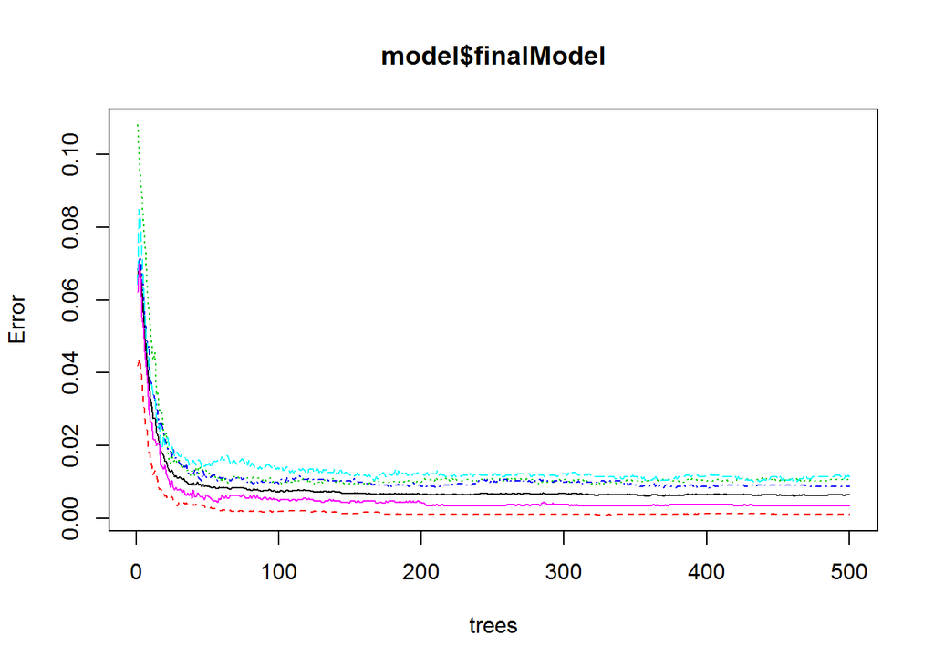

```r
plot(model$finalModel)
```

In this case a model of 100 trees had a very similar error rate to the one trained with 500 trees, so it makes sense to iterate using a model with fewer trees.

## Testing the Model

The model was tested using the cross-validation subset of the cleaned training data. Caret makes it trivial to predict new values using the model and a confusion matrix provides a nice summary of the errors.

```r
crossValidationPredictions <- predict(model, newdata=crossValidationTest)

confusionMatrix(crossValidationPredictions, crossValidationTest$classe)
```

```
## Confusion Matrix and Statistics
##
##           Reference
## Prediction    A    B    C    D    E
##          A 1366    3    0    0    0
##          B    1  923    8    1    0
##          C    0    3  826    7    4
##          D    0    0    4  777    2
##          E    0    0    0    1  876
##
## Overall Statistics
##
##                Accuracy : 0.993
##                  95% CI : (0.99, 0.995)
##     No Information Rate : 0.285
##     P-Value [Acc > NIR] : <2e-16
##
##                   Kappa : 0.991
##  Mcnemar's Test P-Value : NA
##
## Statistics by Class:
##
##                      Class: A Class: B Class: C Class: D Class: E
## Sensitivity             0.999    0.994    0.986    0.989    0.993
## Specificity             0.999    0.997    0.996    0.999    1.000
## Pos Pred Value          0.998    0.989    0.983    0.992    0.999
## Neg Pred Value          1.000    0.998    0.997    0.998    0.998
## Prevalence              0.285    0.193    0.175    0.164    0.184
## Detection Rate          0.284    0.192    0.172    0.162    0.182
## Detection Prevalence    0.285    0.194    0.175    0.163    0.183
## Balanced Accuracy       0.999    0.995    0.991    0.994    0.996
```

In this case we had an accuracy of over 99% so our fear that we overfit the data was reduced. The model looks strong.

## Making Predictions

Quick sanity check of the predictions:

```r
table(testPredictions)
```

```
## testPredictions
## A B C D E
## 7 8 1 1 3
```

Output the predictions to files ready for submission.

```r
# Function takes a character vector and creates a file for each character answer
pml_write_files = function(x){
  n = length(x)
  for(i in 1:n){
    filename = paste0("problem_id_",i,".txt")
    write.table(x[i],file=filename,quote=FALSE,row.names=FALSE,col.names=FALSE)
  }
}

pml_write_files(testPredictions)
```

I submitted the predictions made with the original 500-tree model and all predictions were correct.

## Appendix: Further Work

Tuning the number of trees needed would save much time in training, as would selecting fewer variables to act as predictors. The following lists variables that were important in training the model, some or all of which could be used by future models.

```r
varImp(model)
```

```
## rf variable importance
##
##   variables are sorted by maximum importance across the classes
##   only 20 most important variables shown (out of 53)
##
##                      A    B    C    D     E
## roll_belt         74.3 86.8 84.3 78.9 100.0
## pitch_belt        31.6 94.8 62.2 51.2  41.8
## magnet_dumbbell_y 71.6 69.8 87.9 67.6  60.5
## pitch_forearm     55.5 67.6 85.0 57.4  57.5
## yaw_belt          68.7 68.6 69.5 80.4  55.0
## magnet_dumbbell_z 70.2 55.5 70.6 49.5  52.2
## roll_forearm      55.3 47.3 53.6 42.0  42.9
## accel_forearm_x   22.9 39.0 36.1 52.3  41.0
## accel_dumbbell_y  39.1 38.2 46.5 38.0  41.9
## yaw_arm           43.7 31.1 30.8 36.8  24.8
## gyros_dumbbell_y  42.2 32.5 42.3 31.6  29.0
## gyros_belt_z      26.0 30.4 36.7 23.4  41.3
## accel_dumbbell_z  29.5 37.8 25.9 31.8  38.9
## roll_dumbbell     25.0 36.8 24.9 29.1  35.2
## magnet_belt_z     23.8 36.1 27.4 35.5  28.5
## magnet_arm_z      22.5 35.1 24.9 24.1  22.9
## magnet_belt_y     21.8 34.7 31.3 25.8  30.1
## gyros_dumbbell_x  15.7 34.1 26.2 21.1  17.6
## gyros_arm_y       24.3 33.1 26.8 33.9  26.0
## magnet_belt_x     18.1 33.0 31.6 20.5  29.1
```